# Blue Crab Report: Jess edits

Jess Gorzo

2025-03-20

Jess overall note: My main suggestion ended up being to use arithmetic means for the summaries per bin; I think the basic story is the same as the original report, but with wider error bars better reflecting variability in counts. I went back to what you said about that these are just simple stats as a starting place anyway, and for each subset summary thought of what we are trying to say/capture with the figure.

## Ocean Trawl

We calculated a geometric mean of the number of crabs caught annually, per strata and per cruise. Only shallow and mid-depth strata data were included, due to the de minimis catch in deep strata. The 2020 sampling year was excluded because it only includes data from the January cruise, due to COVID-19 statewide shutdowns.

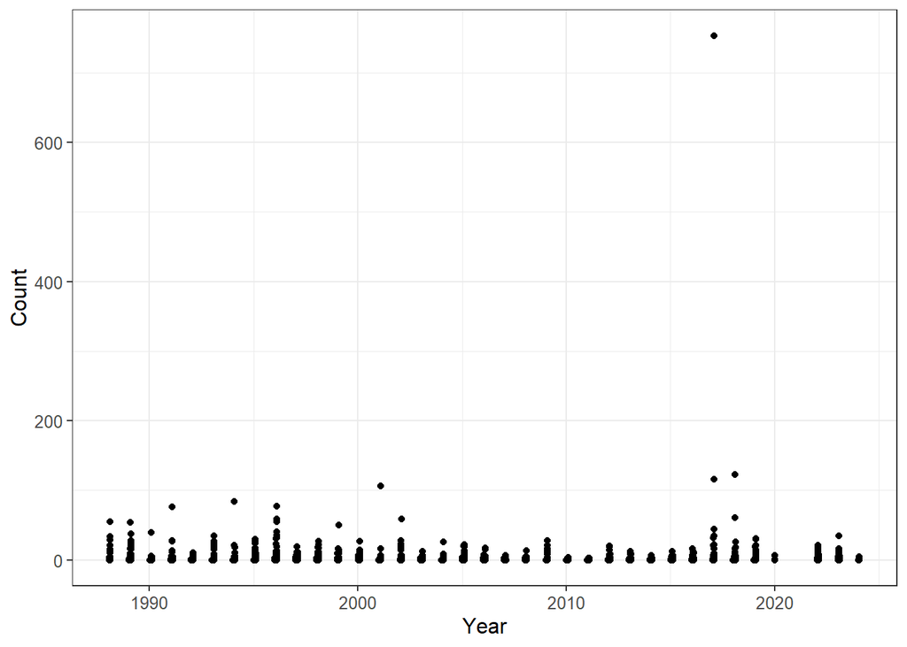

Raw zero-filled counts of crabs per tow

### Annual

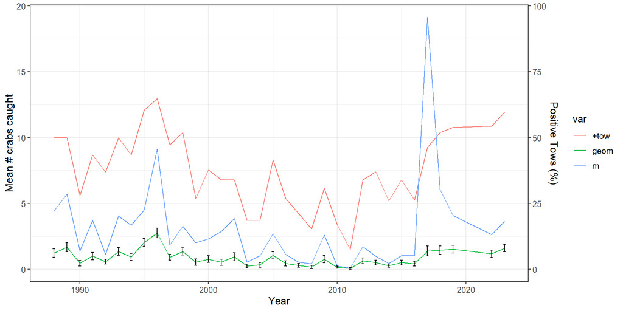

Mean number of crabs caught annually, during cruises 4-5. Deep strata are excluded.

### Per Cruise

Jess note: I think the main point of this figure is to comparatively show crab haul per cruise, so a simple bar plot showing arithmetic mean of crabs (calculated from the zero-filled data) per cruise month suffices to illustrate that, with error bars showing variability per subset. (And generally so on for the rest of these…)

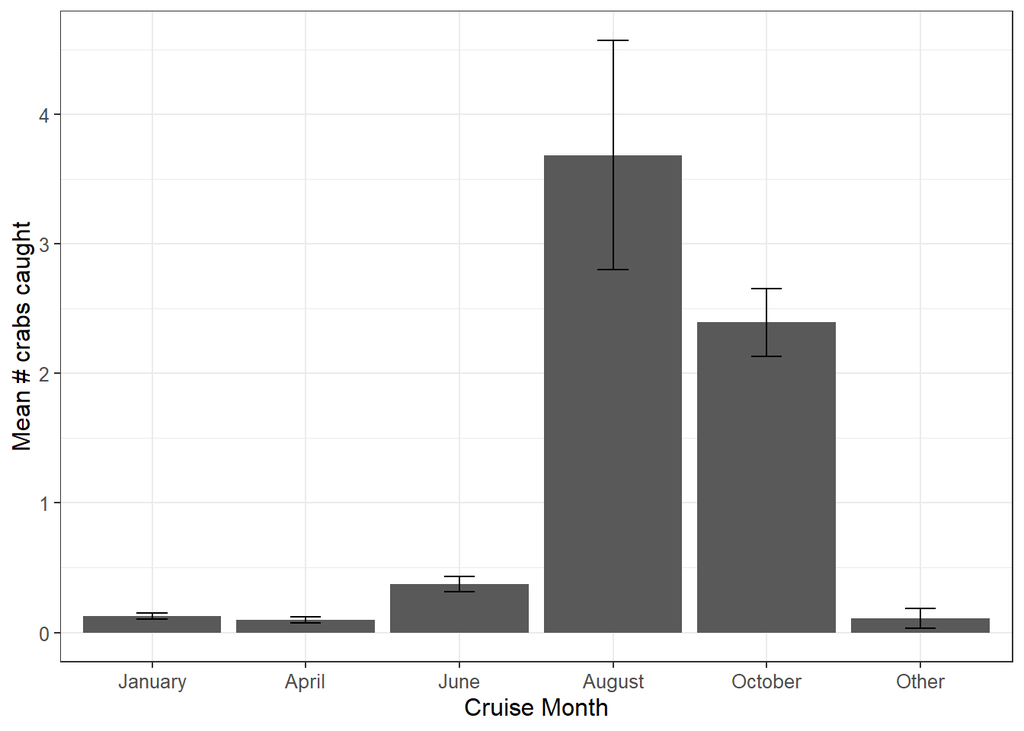

### Per Stratum

Jess note/interpretation for the gist of this plot: shallow strata are better for crabs! However same as above, wide variability around the highest means.

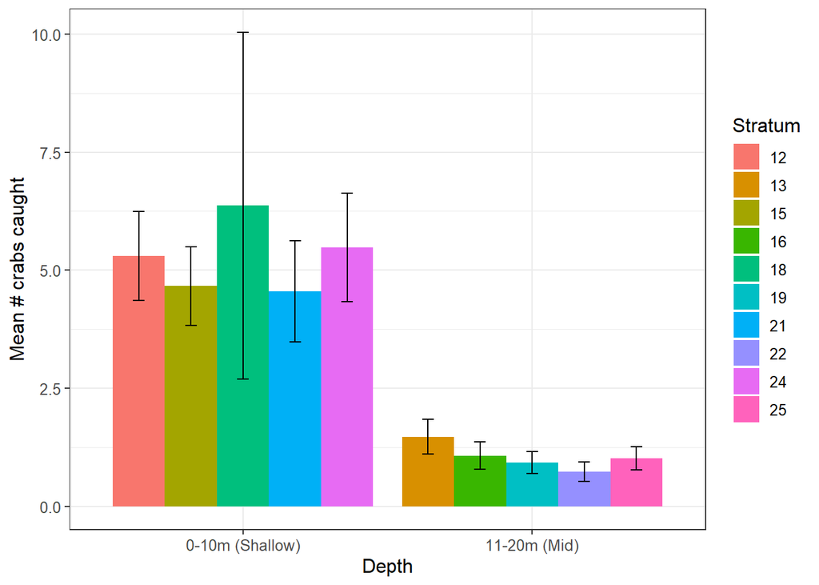

### Lengths

Crabs ranged from 1 cm to 27 cm, with a geometric mean length of 13.0817565 cm.

## Delaware River Striped Bass Recruitment Seine Survey

We calculated a geometric mean of the number of crabs caught monthly, annually, and regionally. Annual and regional means only included data Aug - Oct. The 2020 sampling year was excluded, due to COVID-19 statewide shutdowns.

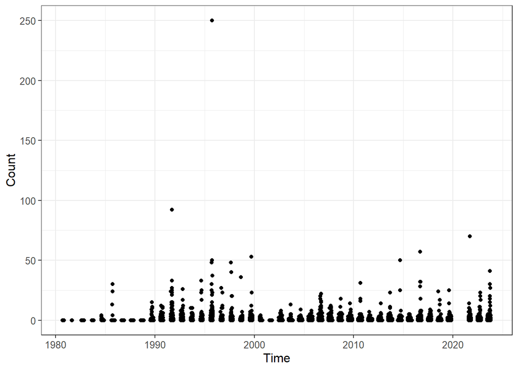

Raw zero-filled counts of crabs per tow

### Annual

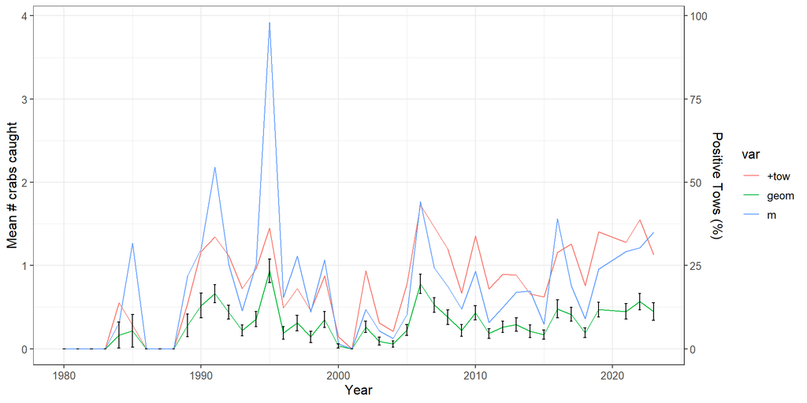

### Monthly

Jess note: Once again, arithmetic mean shows that crabs peak in late summer/early fall, consistent with ocean trawl.

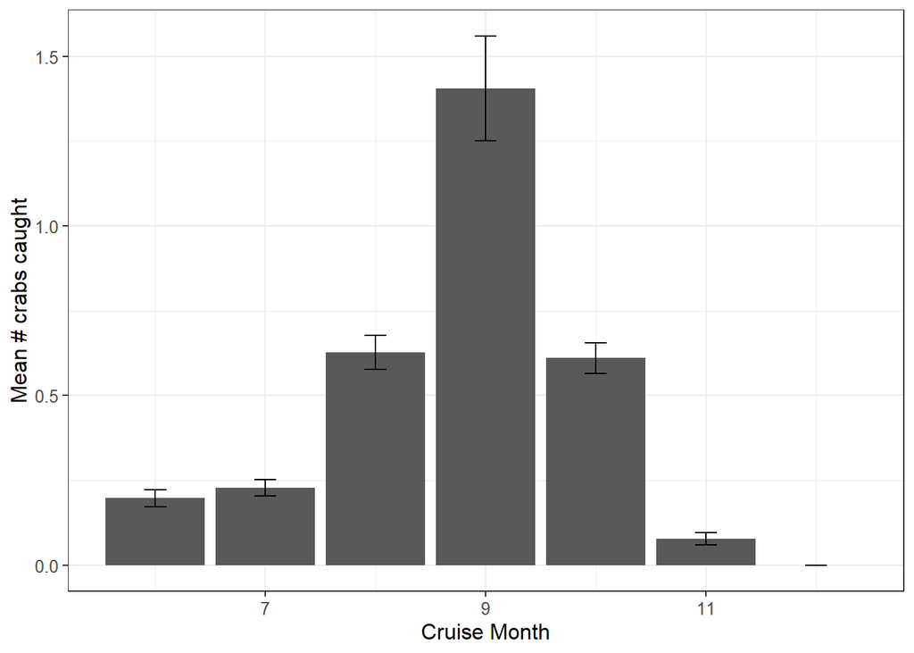

### Per Station

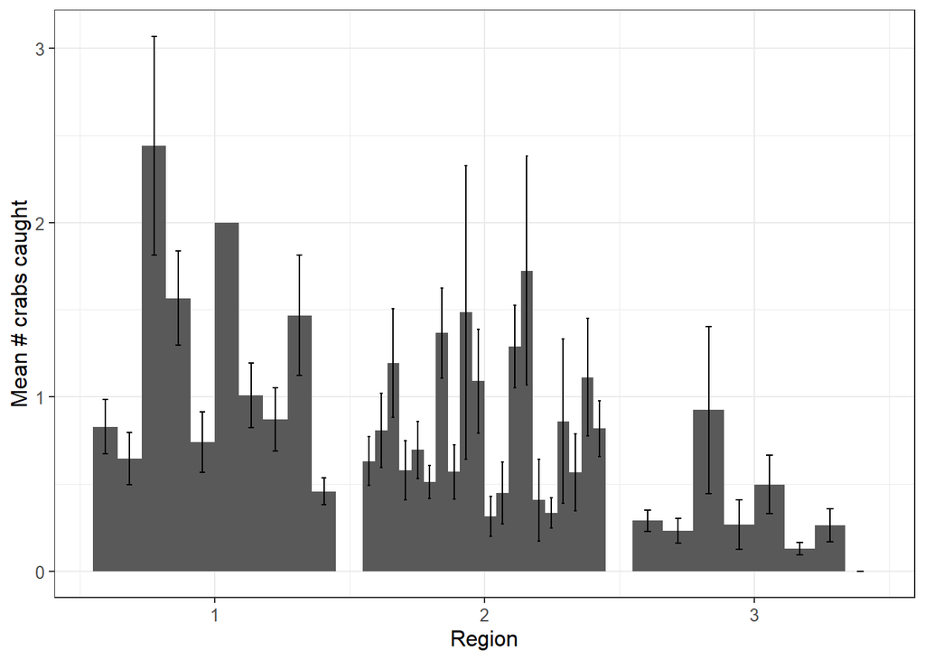

### Lengths

Crabs ranged from 5 mm to 190 mm, with a mean length of 34.046887 mm.

## Delaware Bay Otter Trawl Survey

We calculated a geometric mean of the number of crabs caught monthly, annually, and by station. The 2020 sampling year was excluded, due to COVID-19 statewide shutdowns.

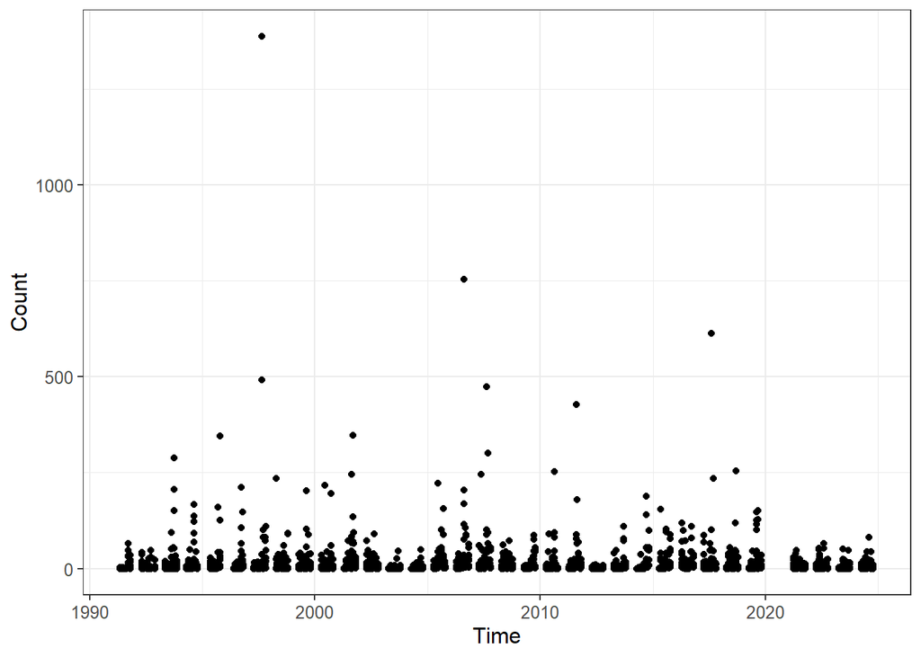

Raw zero-filled counts of crabs per tow

### Annual

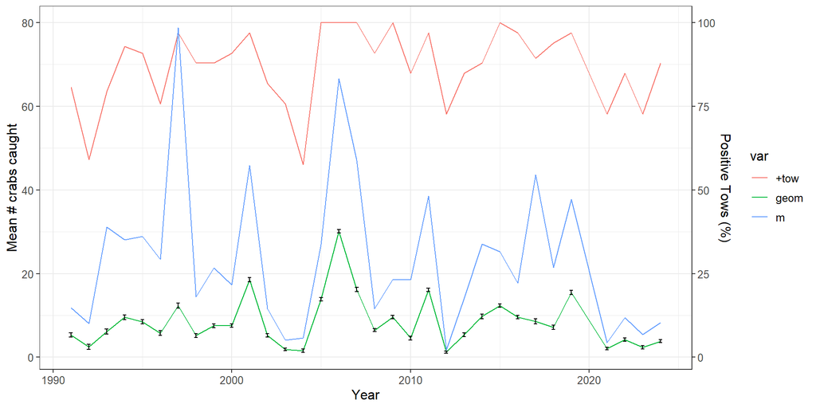

### Monthly

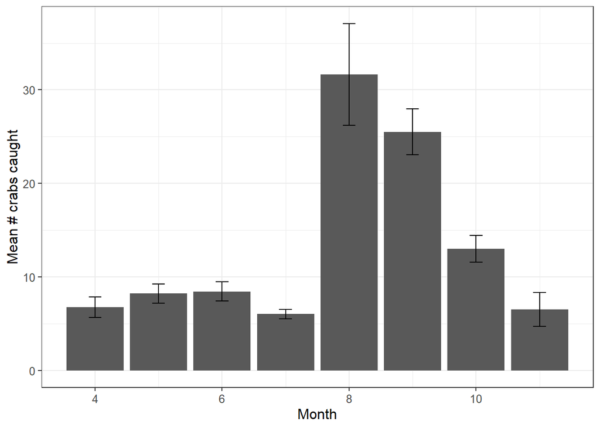

### Per Station

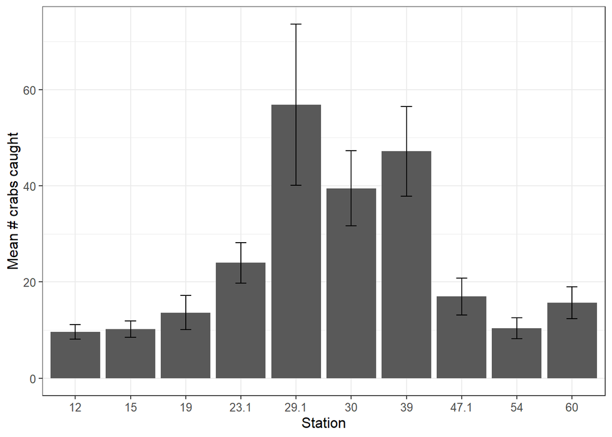

### Lengths

Crabs ranged from 4 mm to 202 mm, with a mean length of 45.8619665 mm.

## River Herring Young-of-the-Year Seine Survey

We calculated a geometric mean of the number of crabs caught monthly, annually, and by station. The 2020 sampling year was excluded, due to COVID-19 statewide shutdowns; 2021 sampling started in August. Stations with extremely low salinity were excluded from the analysis due to a lack of catch of blue crabs.

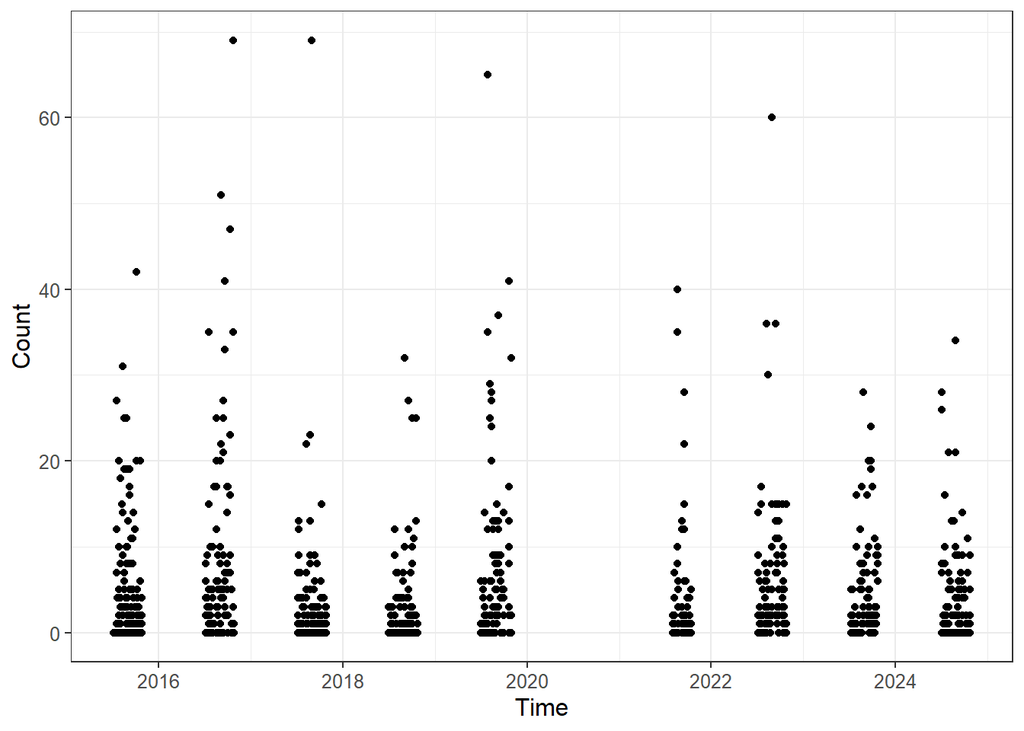

Raw zero-filled counts of crabs per tow

### Annual

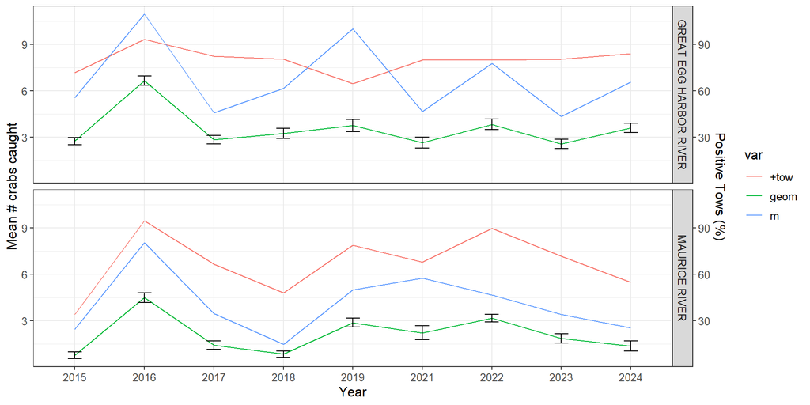

### Monthly

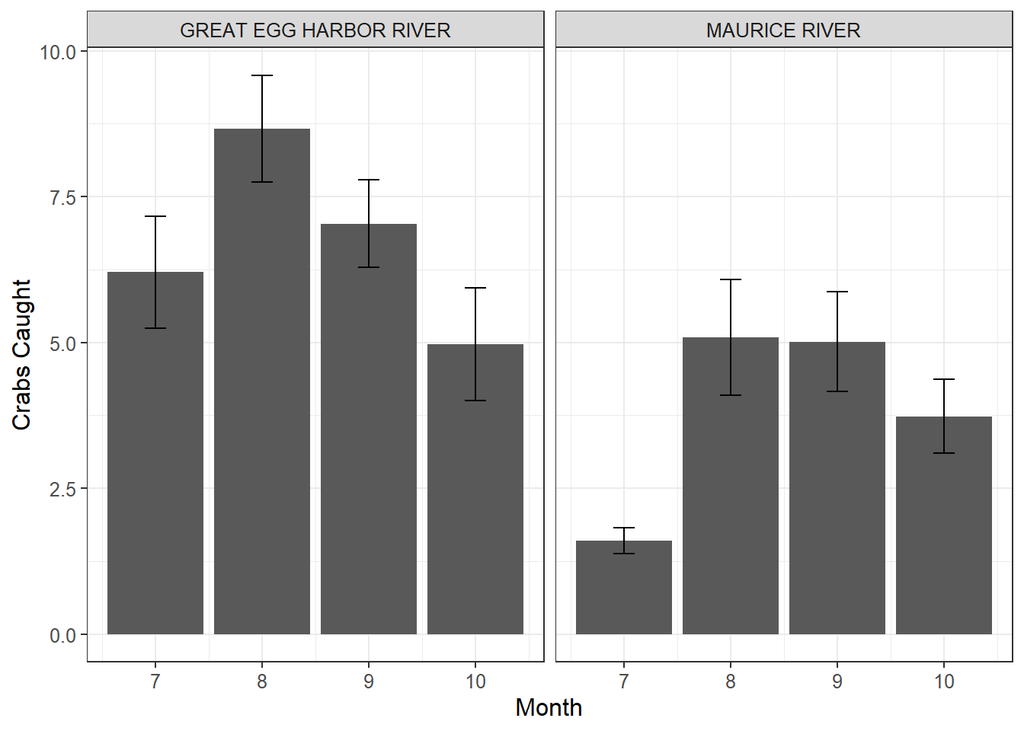

### Per Station

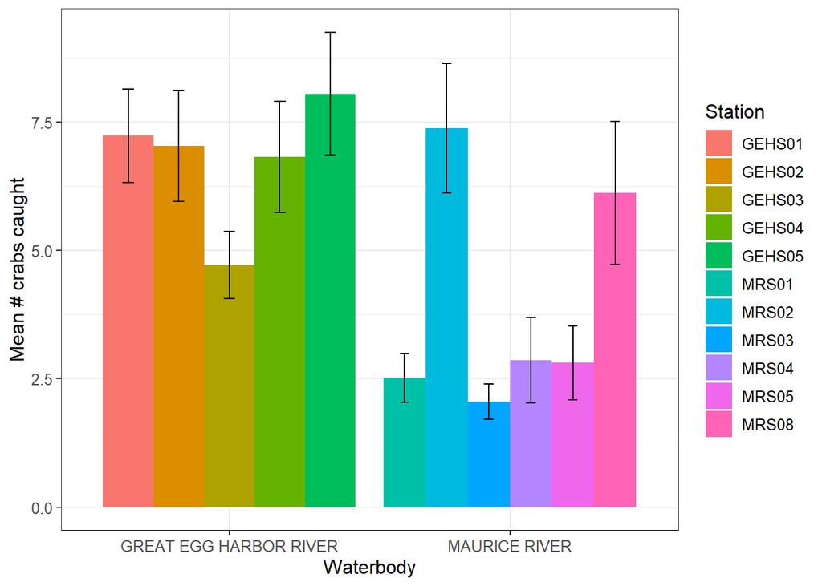

### Lengths

Crabs ranged from 2 mm to 197 mm, with a geometric mean length of 33.0158854 mm.